# Connecting Math Attitudes With STEM Career Attainment: A Latent Class Analysis Approach

Dina Arch

2026-05-26

# Education Longitudinal Study

- BY = Base Year (2002) - 10th grade
  - Completed the baseline survey of high school sophomores in spring term 2002.
- F1 = First follow up (2004) - 12th grade
  - Most sample members were seniors, but some were dropouts or in other grades (early graduates or retained in an earlier grade).
- F2 = Second follow up (2006) - Post-high-school follow-up
- F3 = Third follow up (2012) - Kids are ~26yo

## Item Descriptions

### Base Year Covariates

*English Proficiency* BYS70A: How well student understands English (1 = Very well, 4 = Not at all) BYS70B: How well student speaks English (1 = Very well, 4 = Not at all) BYS70C: How well student reads English (1 = Very well, 4 = Not at all) BYS70D: How well 10th-grader writes English (1 = Very well, 4 = Not at all) BYTM12B: Student behind on schoolwork due to limited proficiency in English BYSTLANG: English if student’s native language

*Demographics* BYSEX: 1 = Male, 2 = Female BYRACE_R: All -5 since restricted BYSES2QU: SES Quartile

### Base Year Indicators

BYS87A: When I do mathematics, I sometimes get totally absorbed BYS87C: Because doing mathematics is fun, I wouldn’t want to give it up BYS87F: Mathematics is important to me personally

BYS89A: I’m confident that I can do an excellent job on my math tests BYS89B: I’m certain I can understand the most difficult material presented in math texts BYS89L: I’m confident I can understand the most complex material presented by my math teacher BYS89R: I’m confident I can do an excellent job on my math assignments BYS89U: I’m certain I can master the skills being taught in my math class

*Math Attitude BYS87 Items*

Description: How much do you agree or disagree with the following statements?

Response options:

1 - Strongly agree

2 - Agree

3 - Disagree

4- Strongly disagree

*Math Self-Efficacy BYS89/F1S18 Items*

Description: How much do you agree or disagree with the following statements?

Response options:

1 - Almost never

2 - Sometimes

3 - Often

4- Almost always

### F1 Indicators

F1S18A: I’m confident that I can do an excellent job on my math tests F1S18B: I’m certain I can understand the most difficult material presented in my math textbooks F1S18C: I’m confident I can understand the most complex material presented by my math teacher F1S18D: I’m confident I can do an excellent job on my math assignments F1S18E: I’m certain I can master the skills being taught in my math class

### Outcomes

F3ONET2CURR: 2 digit code for most recent job F3ONET6CURR: 6 digit code for most recent job F3BYTSCWT: Panel weight

## Read in data

Read in ELS `.sav` file:

```r
els_sav <- read_sav(here("els_data", "els_02_12_byf3pststu_v1_0.sav"))
```

View codebook:

```r
#view_df(els_sav)
```

Save subset:

```r
els_subset <- els_sav %>%
  clean_names() %>%
  dplyr::select(
    stu_id, strat_id, psu,
    bys87a,bys87c,bys87f,bys89a,bys89b,bys89l,bys89r,bys89u,
    f1s18a,f1s18b,f1s18c,f1s18d,f1s18e,
    bys70a,bys70b,bys70c,bys70d,bystlang,bytm12b,bysex,byrace_r,
    byses2qu,f3onet2curr,f3onet6curr, f3bystemoc30, f3bytscwt
         ) %>%
  mutate(school = paste0(strat_id,psu))

view_df(els_subset)

#write_csv(els_subset, here("els_data", "els_dang_analysis.csv"))
```

Read in ELS data file, `els_dang_analysis.csv`.

```r
bys87_items <- c("bys87a","bys87c","bys87f")

f1s18_items <- c("f1s18a","f1s18b","f1s18c","f1s18d","f1s18e")

bys89_items <- c("bys89a","bys89b","bys89l","bys89r","bys89u")

els_data <- read_csv(
  here("els_data", "els_dang_analysis.csv"),
  na = c("-9", "-8", "-6", "-5", "-4", "-7", "-1", "-3", "-2", "-99")
) %>%
  # Dichotomize English proficiency
  mutate(across(
    c(bys70a, bys70b, bys70c, bys70d),
    ~ case_when(. %in% c(1, 2) ~ 1,
                . %in% c(3, 4) ~ 0,
                TRUE ~ NA_real_)
  )) %>%
  mutate(across(
    c(f3onet2curr),
    ~ case_when(is.na(.) ~ NA_real_,
                . %in% c(11, 15, 17, 19, 25, 45, 51) ~ 1,
                TRUE ~ 0)
  )) %>%
  mutate(female = case_match(bysex,
                             2 ~ 1,
                             1 ~ 0,
                             .default = NA_real_)) %>%
  mutate(ses_dichotomized = case_match(
    byses2qu,
    1 ~ 1,
    NA ~ NA,
    .default = 0
  )) %>%
  mutate(across(
    all_of(bys87_items),
    ~ case_when(. %in% c(1, 2) ~ 1,
                . %in% c(3, 4) ~ 0,
                TRUE ~ NA_real_)
  )) %>%
  mutate(across(all_of(c(
    bys89_items, f1s18_items
  )), ~ case_when(
    . %in% c(1, 2) ~ 0,
    . %in% c(3, 4) ~ 1,
    TRUE ~ NA_real_
  )))

summary(els_data)
```

```
##      stu_id          strat_id          psu            bys87a
##  Min.   :101101   Min.   :101.0   Min.   :1.000   Min.   :0.0000
##  1st Qu.:190106   1st Qu.:190.0   1st Qu.:1.000   1st Qu.:0.0000
##  Median :281116   Median :281.0   Median :2.000   Median :1.0000
##  Mean   :279543   Mean   :279.4   Mean   :1.557   Mean   :0.5181
##  3rd Qu.:369205   3rd Qu.:369.0   3rd Qu.:2.000   3rd Qu.:1.0000
##  Max.   :461234   Max.   :461.0   Max.   :3.000   Max.   :1.0000
##                                                   NAs    :4457
##      bys87c           bys87f           bys89a           bys89b
##  Min.   :0.0000   Min.   :0.0000   Min.   :0.0000   Min.   :0.0000
##  1st Qu.:0.0000   1st Qu.:0.0000   1st Qu.:0.0000   1st Qu.:0.0000
##  Median :0.0000   Median :1.0000   Median :0.0000   Median :0.0000
##  Mean   :0.3387   Mean   :0.5108   Mean   :0.4436   Mean   :0.3987
##  3rd Qu.:1.0000   3rd Qu.:1.0000   3rd Qu.:1.0000   3rd Qu.:1.0000
##  Max.   :1.0000   Max.   :1.0000   Max.   :1.0000   Max.   :1.0000
##  NAs    :4523     NAs    :4439     NAs    :4806     NAs    :4765
##      bys89l           bys89r           bys89u          f1s18a
##  Min.   :0.0000   Min.   :0.0000   Min.   :0.000   Min.   :0.0000
##  1st Qu.:0.0000   1st Qu.:0.0000   1st Qu.:0.000   1st Qu.:0.0000
##  Median :0.0000   Median :1.0000   Median :1.000   Median :0.0000
##  Mean   :0.4482   Mean   :0.5168   Mean   :0.534   Mean   :0.4841
##  3rd Qu.:1.0000   3rd Qu.:1.0000   3rd Qu.:1.000   3rd Qu.:1.0000
##  Max.   :1.0000   Max.   :1.0000   Max.   :1.000   Max.   :1.0000
##  NAs    :5150     NAs    :5374     NAs    :5536    NAs    :5860
##      f1s18b           f1s18c           f1s18d           f1s18e
##  Min.   :0.0000   Min.   :0.0000   Min.   :0.0000   Min.   :0.0000
##  1st Qu.:0.0000   1st Qu.:0.0000   1st Qu.:0.0000   1st Qu.:0.0000
##  Median :0.0000   Median :0.0000   Median :1.0000   Median :1.0000
##  Mean   :0.4093   Mean   :0.4506   Mean   :0.6541   Mean   :0.5899
##  3rd Qu.:1.0000   3rd Qu.:1.0000   3rd Qu.:1.0000   3rd Qu.:1.0000
##  Max.   :1.0000   Max.   :1.0000   Max.   :1.0000   Max.   :1.0000
##  NAs    :5883     NAs    :5907     NAs    :5913     NAs    :5903
##      bys70a           bys70b           bys70c           bys70d
##  Min.   :0.0000   Min.   :0.0000   Min.   :0.0000   Min.   :0.0000
##  1st Qu.:1.0000   1st Qu.:1.0000   1st Qu.:1.0000   1st Qu.:1.0000
##  Median :1.0000   Median :1.0000   Median :1.0000   Median :1.0000
##  Mean   :0.9522   Mean   :0.9272   Mean   :0.9222   Mean   :0.8954
##  3rd Qu.:1.0000   3rd Qu.:1.0000   3rd Qu.:1.0000   3rd Qu.:1.0000
##  Max.   :1.0000   Max.   :1.0000   Max.   :1.0000   Max.   :1.0000
##  NAs    :13916    NAs    :13904    NAs    :13923    NAs    :13913
```

[output cut: 9 more lines]

```
##  Min.   :1.000   Min.   :0.000   Mode:logical   Min.   :   0.0   Min.   :1011
##  1st Qu.:2.000   1st Qu.:0.000   NAs :16197     1st Qu.:   0.0   1st Qu.:1901
##  Median :3.000   Median :0.000                  Median : 150.7   Median :2811
##  Mean   :2.574   Mean   :0.271                  Mean   : 200.6   Mean   :2795
##  3rd Qu.:4.000   3rd Qu.:1.000                  3rd Qu.: 310.3   3rd Qu.:3692
##  Max.   :4.000   Max.   :1.000                  Max.   :2163.2   Max.   :4612
##  NAs    :953     NAs    :3401
##      female       ses_dichotomized
##  Min.   :0.0000   Min.   :0.0000
##  1st Qu.:0.0000   1st Qu.:0.0000
##  Median :1.0000   Median :0.0000
##  Mean   :0.5021   Mean   :0.2362
##  3rd Qu.:1.0000   3rd Qu.:0.0000
##  Max.   :1.0000   Max.   :1.0000
##  NAs    :827      NAs    :953
```

```r
summary(factor(els_data$bys70a))
```

```
##     0     1   NAs
##   109  2172 13916
```

```r
summary(factor(els_data$bys70b))
```

```
##     0     1   NAs
##   167  2126 13904
```

```r
summary(factor(els_data$bys70c))
```

```
##     0     1   NAs
##   177  2097 13923
```

```r
summary(factor(els_data$bys70d))
```

```
##     0     1   NAs
##   239  2045 13913
```

```r
summary(factor(els_data$bystlang))
```

```
##     0     1   NAs
##  2586 12658   953
```

```r
summary(factor(els_data$f3onet2curr))
```

```
##    0    1  NAs
## 9328 3468 3401
```

```r
summary(factor(els_data$female))
```

```
##    0    1  NAs
## 7653 7717  827
```

```r
summary(factor(els_data$bysex))
```

```
##    1    2  NAs
## 7653 7717  827
```

```r
summary(factor(els_data$byses2qu))
```

```
##    1    2    3    4  NAs
## 3600 3590 3753 4301  953
```

```r
summary(factor(els_data$ses_dichotomized))
```

```
##     0     1   NAs
## 11644  3600   953
```

## Descriptive Statistics

*Linguistic Minority*

“Respondents were classified as linguistic minority if they reported that English was not their first language and they responded that they read,speak, write, and/or understand English well. Respondents were classified as native English speakers if they indicated they speak English as a first language and they read, speak, write, and understand English well. Using these criteria, among the total 8,790 students, 7,490 (85.2%) were classified as native English speakers, 1,040 (11.8%) were classified as linguistic minority students, and 260 (3.0%) were classified as ELLs.” (page 8)

BYS70A: How well student understands English (1 = Very well, 4 = Not at all) but already dichotomized BYS70B: How well student speaks English (1 = Very well, 4 = Not at all) but already dichotomized BYS70C: How well student reads English (1 = Very well, 4 = Not at all) but already dichotomized BYS70D: How well 10th-grader writes English (1 = Very well, 4 = Not at all) but already dichotomized BYTM12B: Student behind on schoolwork due to limited proficiency in English

```r
ling_min <- els_subset %>%
  mutate(across(where(is.labelled), zap_labels)) %>%
  replace_with_na_all(condition = ~.x %in% c(-9,-8,-6,-5,-4,-7,-1,-3,-2,-99)) %>%
  select(bys70a,bys70b,bys70c,bys70d,bytm12b)

f <- All(ling_min) ~ Mean + SD + Min + Median + Max + Histogram

datasummary(f, els_subset, output="markdown")

summary(factor(ling_min$bys70a))
summary(factor(ling_min$bys70b))
summary(factor(ling_min$bys70c))
summary(factor(ling_min$bys70d))
summary(factor(ling_min$bytm12b))


# Trying to create the linguistic minority variable:
ling_minority_var <- els_data %>%
  mutate(
    lang_status = case_when(
      # Condition A: Native English Speaker
      # Native language is English AND proficient in all 4 domains
      bystlang == 1 & bys70a == 1 & bys70b == 1 & bys70c == 1 & bys70d == 1
        ~ "Native English Speaker",

      # Condition B: Linguistic Minority
      # Not native English speaker, BUT reads, speaks, writes, and/or understands well
      bystlang == 0 & (bys70a == 1 | bys70b == 1 | bys70c == 1 | bys70d == 1)
        ~ "Linguistic Minority",

      # Condition C: ELL (English Language Learner)
      # Not native English speaker AND has limited proficiency / behind in schoolwork
      bystlang == 0 & (bytm12b == 1 | (bys70a != 1 & bys70b != 1 & bys70c != 1 & bys70d != 1))
        ~ "ELL",

      # If data is missing for vital logic pieces, preserve it as NA
      TRUE ~ NA_character_
    ),
    # Convert to a factor for clean modeling/summaries later
    lang_status = factor(lang_status, levels = c("Native English Speaker", "Linguistic Minority", "ELL"))
  )


summary(factor(ling_minority_var$lang_status))
```

```r
math_subset <- els_data %>%
  select(bys87a,bys87c,bys87f,bys89a,bys89b,bys89l,bys89r,bys89u,f1s18a,f1s18b,f1s18c,f1s18d,f1s18e)
```

Descriptive

```r
f <- All(math_subset) ~ Mean + SD + Min + Median + Max + Histogram

datasummary(f, els_data, output="markdown")
```

|  | Mean | SD | Min | Median | Max | Histogram |
| --- | --- | --- | --- | --- | --- | --- |
| bys87a | 0.52 | 0.50 | 0.00 | 1.00 | 1.00 | ▇▇ |
| bys87c | 0.34 | 0.47 | 0.00 | 0.00 | 1.00 | ▇▄ |
| bys87f | 0.51 | 0.50 | 0.00 | 1.00 | 1.00 | ▇▇ |
| bys89a | 0.44 | 0.50 | 0.00 | 0.00 | 1.00 | ▇▆ |
| bys89b | 0.40 | 0.49 | 0.00 | 0.00 | 1.00 | ▇▅ |
| bys89l | 0.45 | 0.50 | 0.00 | 0.00 | 1.00 | ▇▆ |
| bys89r | 0.52 | 0.50 | 0.00 | 1.00 | 1.00 | ▇▇ |
| bys89u | 0.53 | 0.50 | 0.00 | 1.00 | 1.00 | ▆▇ |
| f1s18a | 0.48 | 0.50 | 0.00 | 0.00 | 1.00 | ▇▇ |
| f1s18b | 0.41 | 0.49 | 0.00 | 0.00 | 1.00 | ▇▅ |
| f1s18c | 0.45 | 0.50 | 0.00 | 0.00 | 1.00 | ▇▆ |
| f1s18d | 0.65 | 0.48 | 0.00 | 1.00 | 1.00 | ▄▇ |
| f1s18e | 0.59 | 0.49 | 0.00 | 1.00 | 1.00 | ▅▇ |

Weighted average

```r
bys87_items <- c("bys87a","bys87c","bys87f")

f1s18_items <- c("f1s18a","f1s18b","f1s18c","f1s18d","f1s18e")

bys89_items <- c("bys89a","bys89b","bys89l","bys89r","bys89u")

math_binary_weighted <- els_data %>%
  summarise(across(c(all_of(bys87_items), all_of(c(bys89_items, f1s18_items))),
                   list(
                     w_mean = ~ weighted.mean(.x, f3bytscwt, na.rm = TRUE),
                     w_sd = ~ {
                       keep <- !is.na(.x) & !is.na(f3bytscwt)
                       x <- .x[keep]
                       w_raw <- f3bytscwt[keep]
                       w <- w_raw / sum(w_raw)
                       mu <- sum(w * x)
                       sqrt(sum(w * (x - mu)^2))
                     }
                   ),
                   .names = "{.col}_{.fn}"
  )) %>%
  pivot_longer(
    cols = everything(),
    names_to = c("item", ".value"),
    names_pattern = "(.*)_(w_mean|w_sd)"
  )

math_binary_weighted
```

```
## # A tibble: 13 × 3
##    item   w_mean  w_sd
##    <chr>   <dbl> <dbl>
##  1 bys87a  0.508 0.500
##  2 bys87c  0.333 0.471
##  3 bys87f  0.504 0.500
##  4 bys89a  0.450 0.497
##  5 bys89b  0.401 0.490
##  6 bys89l  0.452 0.498
##  7 bys89r  0.520 0.500
##  8 bys89u  0.538 0.499
##  9 f1s18a  0.483 0.500
## 10 f1s18b  0.407 0.491
## 11 f1s18c  0.452 0.498
## 12 f1s18d  0.655 0.475
## 13 f1s18e  0.589 0.492
```

```r
library(tidyverse)
library(gt)

item_labels <- tibble(
  item = c(
    "bys87a", "bys87c", "bys87f",
    "f1s18a", "f1s18b", "f1s18c", "f1s18d", "f1s18e",
    "bys89a", "bys89b", "bys89l", "bys89r", "bys89u"
  ),
  scale = c(
    rep("Math attitudes", 3),
    rep("Math self-efficacy", 5),
    rep("Math experiences", 5)
  ),
  item_label = c(
    "I enjoy math",
    "Math is one of my best subjects",
    "Math is useful for my future",
    "Certain I can understand math",
    "Certain I can do well in math",
    "Certain I can learn math",
    "Certain I can master math skills",
    "Certain I can complete math assignments",
    "Took advanced math",
    "Participated in math club",
    "Worked hard in math",
    "Talked with teacher about math",
    "Planned to take more math"
  )
)

math_binary_weighted_table <- math_binary_weighted %>%
  left_join(item_labels, by = "item") %>%
  mutate(
    percent_endorsed = w_mean * 100,
    sd = w_sd
  ) %>%
  select(scale, item, item_label, percent_endorsed, sd)

math_binary_weighted_table %>%
  gt(groupname_col = "scale") %>%
  cols_label(
    item = "Item",
    item_label = "Item wording",
    percent_endorsed = "% endorsed",
    sd = "SD"
  ) %>%
  fmt_number(
    columns = c(percent_endorsed, sd),
    decimals = 2
  ) %>%
  tab_header(
    title = "Weighted Descriptive Statistics for Binary Math Indicators",
    subtitle = "Weighted means represent the percentage endorsing the focal response category"
  ) %>%
  tab_options(
    table.font.size = 13,
    heading.title.font.size = 16,
    heading.subtitle.font.size = 12,
    row_group.font.weight = "bold",
    column_labels.font.weight = "bold"
  )
```

Weighted Descriptive Statistics for Binary Math Indicators

Weighted means represent the percentage endorsing the focal response category

[output not shown]

Proportions

```r
# Dichotomize
math_binary <- els_data %>%
  select(bys87_items,bys89_items,f1s18_items, f3bytscwt, f3onet2curr, bystlang, stu_id)

# Set up data to find proportions of binary indicators
ds <- math_binary %>%
  select(-f3bytscwt, -bystlang, -stu_id, -f3onet2curr) %>%
  pivot_longer(
    cols = everything(),
    names_to = "variable",
    values_to = "value"
  )

# Create table of variables and counts, then find proportions and round to 3 decimal places
prop_df <- ds %>%
  count(variable, value) %>%
  group_by(variable) %>%
  mutate(prop = n / sum(n)) %>%
  ungroup() %>%
  mutate(prop = round(prop, 3))


# Make it a gt() table
prop_table <- prop_df %>%
  gt(groupname_col = "variable", rowname_col = "value") %>%
  tab_stubhead(label = md("*Values*")) %>%
  tab_header(
    md(
      "Variable Proportions"
    )
  ) %>%
  cols_label(
    variable = md("*Variable*"),
    value = md("*Value*"),
    n = md("*N*"),
    prop = md("*Proportion*")
  )

prop_table
```

Variable Proportions

| *Values* | *N* | *Proportion* |
| --- | --- | --- |
| bys87a |  |  |
| 0 | 5658 | 0.349 |
| 1 | 6082 | 0.376 |
| NA | 4457 | 0.275 |
| bys87c |  |  |
| 0 | 7720 | 0.477 |
| 1 | 3954 | 0.244 |
| NA | 4523 | 0.279 |
| bys87f |  |  |
| 0 | 5752 | 0.355 |
| 1 | 6006 | 0.371 |
| NA | 4439 | 0.274 |
| bys89a |  |  |
| 0 | 6338 | 0.391 |
| 1 | 5053 | 0.312 |
| NA | 4806 | 0.297 |
| bys89b |  |  |
| 0 | 6874 | 0.424 |
| 1 | 4558 | 0.281 |
| NA | 4765 | 0.294 |
| bys89l |  |  |
| 0 | 6096 | 0.376 |
| 1 | 4951 | 0.306 |
| NA | 5150 | 0.318 |
| bys89r |  |  |
| 0 | 5230 | 0.323 |
| 1 | 5593 | 0.345 |
| NA | 5374 | 0.332 |
| bys89u |  |  |
| 0 | 4968 | 0.307 |
| 1 | 5693 | 0.351 |
| NA | 5536 | 0.342 |
| f1s18a |  |  |
| 0 | 5333 | 0.329 |
| 1 | 5004 | 0.309 |
| NA | 5860 | 0.362 |
| f1s18b |  |  |
| 0 | 6092 | 0.376 |
| 1 | 4222 | 0.261 |
| NA | 5883 | 0.363 |
| f1s18c |  |  |
| 0 | 5653 | 0.349 |
| 1 | 4637 | 0.286 |
| NA | 5907 | 0.365 |
| f1s18d |  |  |
| 0 | 3557 | 0.220 |
| 1 | 6727 | 0.415 |
| NA | 5913 | 0.365 |
| f1s18e |  |  |
| 0 | 4222 | 0.261 |
| 1 | 6072 | 0.375 |
| NA | 5903 | 0.364 |

```r
psych::describe(math_binary)
```

```
##             vars     n      mean        sd    median   trimmed       mad    min
## bys87a         1 11740      0.52      0.50      1.00      0.52      0.00      0
## bys87c         2 11674      0.34      0.47      0.00      0.30      0.00      0
## bys87f         3 11758      0.51      0.50      1.00      0.51      0.00      0
## bys89a         4 11391      0.44      0.50      0.00      0.43      0.00      0
## bys89b         5 11432      0.40      0.49      0.00      0.37      0.00      0
## bys89l         6 11047      0.45      0.50      0.00      0.44      0.00      0
## bys89r         7 10823      0.52      0.50      1.00      0.52      0.00      0
## bys89u         8 10661      0.53      0.50      1.00      0.54      0.00      0
## f1s18a         9 10337      0.48      0.50      0.00      0.48      0.00      0
## f1s18b        10 10314      0.41      0.49      0.00      0.39      0.00      0
## f1s18c        11 10290      0.45      0.50      0.00      0.44      0.00      0
## f1s18d        12 10284      0.65      0.48      1.00      0.69      0.00      0
## f1s18e        13 10294      0.59      0.49      1.00      0.61      0.00      0
## f3bytscwt     14 16197    200.58    212.77    150.69    167.57    223.42      0
## f3onet2curr   15 12796      0.27      0.44      0.00      0.21      0.00      0
## bystlang      16 15244      0.83      0.38      1.00      0.91      0.00      0
## stu_id        17 16197 279542.70 104263.77 281116.00 279551.71 133070.76 101101
##                   max     range  skew kurtosis     se
## bys87a           1.00      1.00 -0.07    -1.99   0.00
## bys87c           1.00      1.00  0.68    -1.54   0.00
## bys87f           1.00      1.00 -0.04    -2.00   0.00
## bys89a           1.00      1.00  0.23    -1.95   0.00
## bys89b           1.00      1.00  0.41    -1.83   0.00
## bys89l           1.00      1.00  0.21    -1.96   0.00
## bys89r           1.00      1.00 -0.07    -2.00   0.00
## bys89u           1.00      1.00 -0.14    -1.98   0.00
## f1s18a           1.00      1.00  0.06    -2.00   0.00
## f1s18b           1.00      1.00  0.37    -1.86   0.00
## f1s18c           1.00      1.00  0.20    -1.96   0.00
## f1s18d           1.00      1.00 -0.65    -1.58   0.00
## f1s18e           1.00      1.00 -0.37    -1.87   0.00
## f3bytscwt     2163.17   2163.17  1.43     3.18   1.67
## f3onet2curr      1.00      1.00  1.03    -0.94   0.00
## bystlang         1.00      1.00 -1.76     1.10   0.00
## stu_id      461234.00 360133.00  0.00    -1.20 819.25
```

```r
# Item labels
item_labels <- tibble(
  variable = c(
    "bys87a", "bys87c", "bys87f",
    "bys89a", "bys89b", "bys89l", "bys89r", "bys89u",
    "f1s18a", "f1s18b", "f1s18c", "f1s18d", "f1s18e"
  ),
  scale = c(
    rep("Math attitudes", 3),
    rep("Math experiences", 5),
    rep("Math self-efficacy", 5)
  ),
  item_label = c(
    "I enjoy math",
    "Math is one of my best subjects",
    "Math is useful for my future",
    "Took advanced math",
    "Participated in math club",
    "Worked hard in math",
    "Talked with teacher about math",
    "Planned to take more math",
    "Certain I can understand math",
    "Certain I can do well in math",
    "Certain I can learn math",
    "Certain I can master math skills",
    "Certain I can complete math assignments"
  )
)

prop_table_data <- math_binary %>%
  select(all_of(c(bys87_items, bys89_items, f1s18_items))) %>%
  pivot_longer(
    cols = everything(),
    names_to = "variable",
    values_to = "value"
  ) %>%
  filter(!is.na(value)) %>%
  count(variable, value, name = "n") %>%
  group_by(variable) %>%
  mutate(
    total_n = sum(n),
    prop = n / total_n
  ) %>%
  ungroup() %>%
  left_join(item_labels, by = "variable") %>%
  mutate(
    value_label = case_when(
      value == 1 ~ "1 = endorsed",
      value == 0 ~ "0 = not endorsed"
    )
  ) %>%
  select(scale, variable, item_label, value_label, n, total_n, prop)
```

```r
prop_endorsed_table <- prop_table_data %>%
  filter(value_label == "1 = endorsed") %>%
  select(scale, variable, item_label, n, total_n, prop) %>%
  gt(groupname_col = "scale") %>%
  cols_label(
    variable = "Item",
    item_label = "Item wording",
    n = "Endorsed N",
    total_n = "Valid N",
    prop = "% endorsed"
  ) %>%
  fmt_percent(
    columns = prop,
    decimals = 1
  ) %>%
  tab_header(
    title = "Unweighted Endorsement Rates for Binary Math Indicators",
    subtitle = "Endorsement refers to the response category recoded as 1"
  ) %>%
  tab_options(
    table.font.size = 13,
    heading.title.font.size = 16,
    heading.subtitle.font.size = 12,
    row_group.font.weight = "bold",
    column_labels.font.weight = "bold"
  )

prop_endorsed_table
```

Unweighted Endorsement Rates for Binary Math Indicators

Endorsement refers to the response category recoded as 1

[output not shown]

## Math Attitudes & Self-Efficacy

### Full Sample

Basic analysis

```r
basic_t1  <- mplusObject(

   TITLE = glue("Basic - T1"),

   VARIABLE =
    "categorical = bys87a,bys87c,bys87f,bys89a,
    bys89b,bys89l,bys89r,bys89u;
     usevar = bys87a,bys87c,bys87f,bys89a,
    bys89b,bys89l,bys89r,bys89u;

    WEIGHT = f3bytscwt;",

  ANALYSIS =
   "type = basic;",

  OUTPUT = "sampstat;",

  usevariables = colnames(math_binary),
  rdata = math_binary)

basic_t1_fit <- mplusModeler(basic_t1,
                 dataout=here("basic.dat"),
                 modelout=here("basic.inp"),
                 check=TRUE, run = TRUE, hashfilename = FALSE)
```

Enumeration

```r
if (!dir.exists("enumeration")) {
  dir.create("enumeration", recursive = TRUE)
}

t1_enum <- lapply(1:6, function(k) {
  enum_t1  <- mplusObject(

   TITLE = glue("Class {k} Math Attitudes & Efficacy - T1"),

   VARIABLE = glue(
    "categorical = bys87a,bys87c,bys87f,bys89a,
    bys89b,bys89l,bys89r,bys89u;
     usevar = bys87a,bys87c,bys87f,bys89a,
    bys89b,bys89l,bys89r,bys89u;

    WEIGHT = f3bytscwt;

     classes = c({k});"),

  ANALYSIS =
   "estimator = mlr;
    type = mixture;
    starts = 500 100;
    processors = 12;",

  OUTPUT = "sampstat residual tech11 tech14;",

  usevariables = colnames(math_binary),
  rdata = math_binary)

enum_t1_fit <- mplusModeler(enum_t1,
                 dataout=here("enumeration","enum.dat"),
                 modelout=glue(here("enumeration","c{k}_math_weighted.inp")),
                 check=TRUE, run = TRUE, hashfilename = FALSE)
})
```

Model Fit Summary

```r
source(here("functions", "extract_mplus_info.R"))
source(here("functions","enum_table.R"))

# Define the directory where all of the .out files are located.
output_dir <- here("enumeration")

# Get all .out files
output_files <- list.files(output_dir, pattern = "\\.out$", full.names = TRUE)

# Process all .out files into one dataframe
final_data <- map_dfr(output_files, extract_mplus_info_extended)

# Extract Sample_Size from final_data
sample_size <- unique(final_data$Sample_Size)

output_enum <- readModels(here("enumeration"), quiet = TRUE)
enum_table_weights(output_enum)
```

**Model Fit Summary Table**<sup>1</sup>

| Classes | Par | *LL* | % Converged | % Replicated | Model Fit Indices BIC | Model Fit Indices aBIC | Model Fit Indices CAIC | Model Fit Indices AWE | LRTs VLMR | Smallest Class n (%) |
| --- | --- | --- | --- | --- | --- | --- | --- | --- | --- | --- |
| Class 1 Math Attitudes & Efficacy - T1 | 8 | −62,206.05 | 100% | 100% | 124,487.34 | 124,461.91 | 124,495.34 | 124,586.58 | – | 12146 (100%) |
| Class 2 Math Attitudes & Efficacy - T1 | 17 | −48,467.32 | 100% | 100% | 97,094.51 | 97,040.49 | 97,111.51 | 97,305.39 | <.001 | 5607 (46.2%) |
| Class 3 Math Attitudes & Efficacy - T1 | 26 | −47,104.20 | 55% | 62% | 94,452.93 | 94,370.30 | 94,478.93 | 94,775.45 | <.001 | 3782 (31.1%) |
| Class 4 Math Attitudes & Efficacy - T1 | 35 | −45,812.59 | 78% | 100% | 91,954.35 | 91,843.12 | 91,989.35 | 92,388.51 | <.001 | 2252 (18.5%) |
| Class 5 Math Attitudes & Efficacy - T1 | 44 | −45,344.55 | 76% | 92% | 91,102.92 | 90,963.09 | 91,146.92 | 91,648.73 | <.001 | 1584 (13%) |
| Class 6 Math Attitudes & Efficacy - T1 | 53 | −45,109.87 | 41% | 93% | 90,718.20 | 90,549.77 | 90,771.20 | 91,375.65 | 0.01 | 899 (7.4%) |

<sup>1</sup> *Note.* Par = Parameters; *LL* = model log likelihood; BIC = Bayesian information criterion; aBIC = sample size adjusted BIC; CAIC = consistent Akaike information criterion; AWE = approximate weight of evidence criterion; VLMR = Vuong-Lo-Mendell-Rubin adjusted likelihood ratio test p-value; *cmPk* = approximate correct model probability.

IC Plot

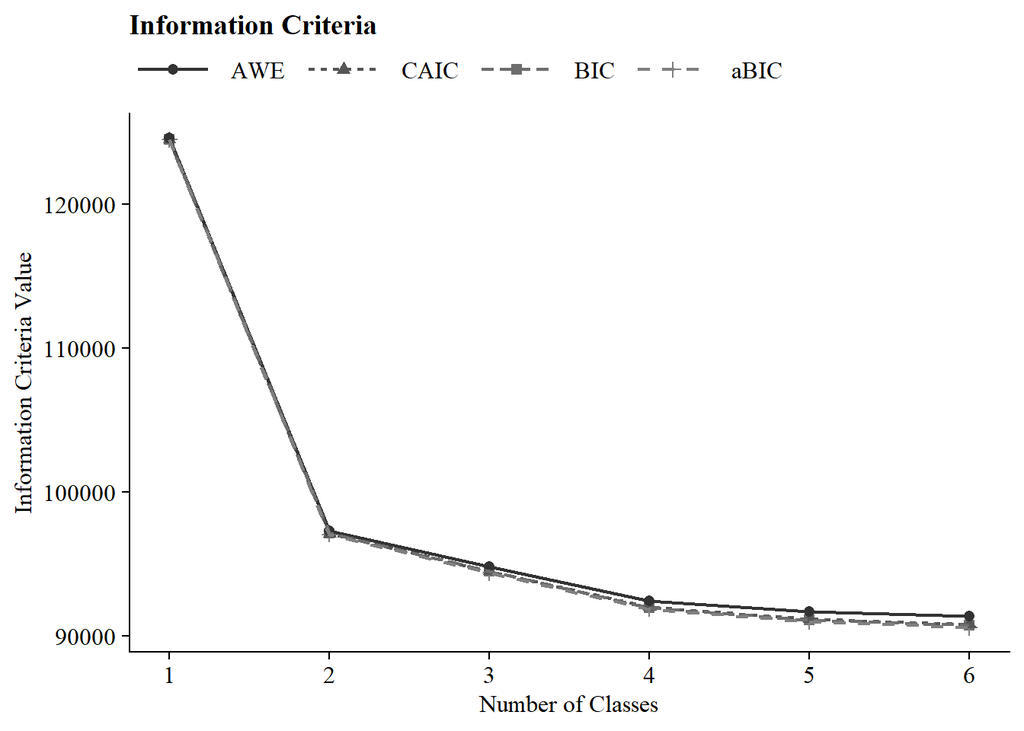

```r
source(here("functions","ic_plot_lca.R"))
ic_plot2(output_enum)
```

Plot LCA:

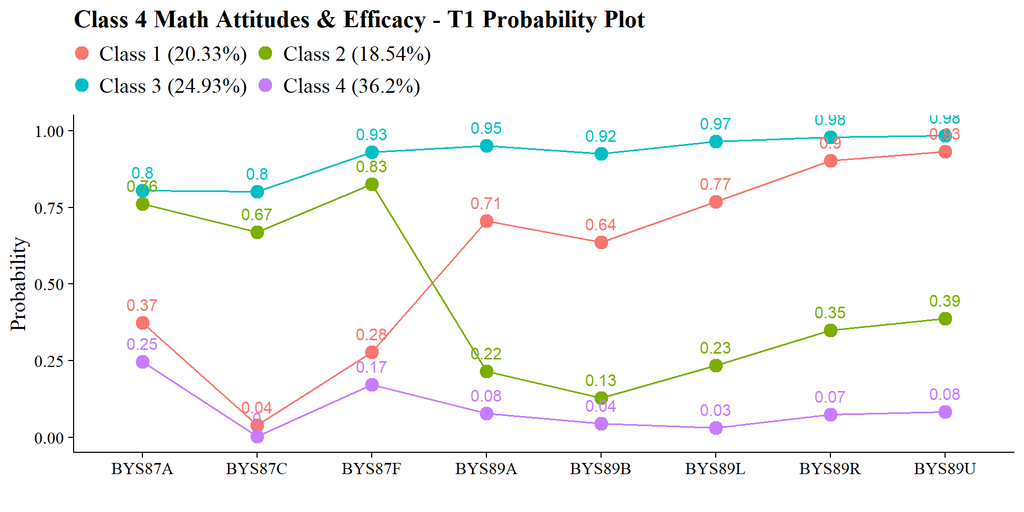

```r
source(here("functions","plot_lca.R"))

plot_lca(output_enum$c4_math_weighted.out)
```

## Manual ML Three-step

### Step 1 - Class Enumeration w/ Auxiliary Specification

```r
step1  <- mplusObject(

  TITLE = "Step 1 - Three-Step",

  VARIABLE =
  "categorical = bys87a,bys87c,bys87f,bys89a,
    bys89b,bys89l,bys89r,bys89u;
   usevar = bys87a,bys87c,bys87f,bys89a,
    bys89b,bys89l,bys89r,bys89u;

   classes = c(4);

   auxiliary =
   female
   ses_dichotomized
   f3onet2curr;

  WEIGHT = f3bytscwt;",

  ANALYSIS =
   "estimator = mlr;
    type = mixture;
    starts = 0;
    optseed = 399671;",

  SAVEDATA =
   "File=savedata.dat;
    Save=cprob;",

  OUTPUT = "residual tech11 tech14",

  usevariables = colnames(els_data),
  rdata = els_data)

step1_fit <- mplusModeler(step1,
                            dataout=here("three_step", "Step1.dat"),
                            modelout=here("three_step", "one.inp") ,
                            check=TRUE, run = TRUE, hashfilename = FALSE)
```

Plot LCA

Class 1 = Low Math Attitudes, High Self-Efficacy (20.33%) Class 2 = High Math Attitudes, Low Self-Efficacy (18.546%) Class 3 = High Math Attitudes, High Self-Efficacy (24.93%) Class 4 = Low Math Attitudes, Low Self-Efficacy (36.2%)

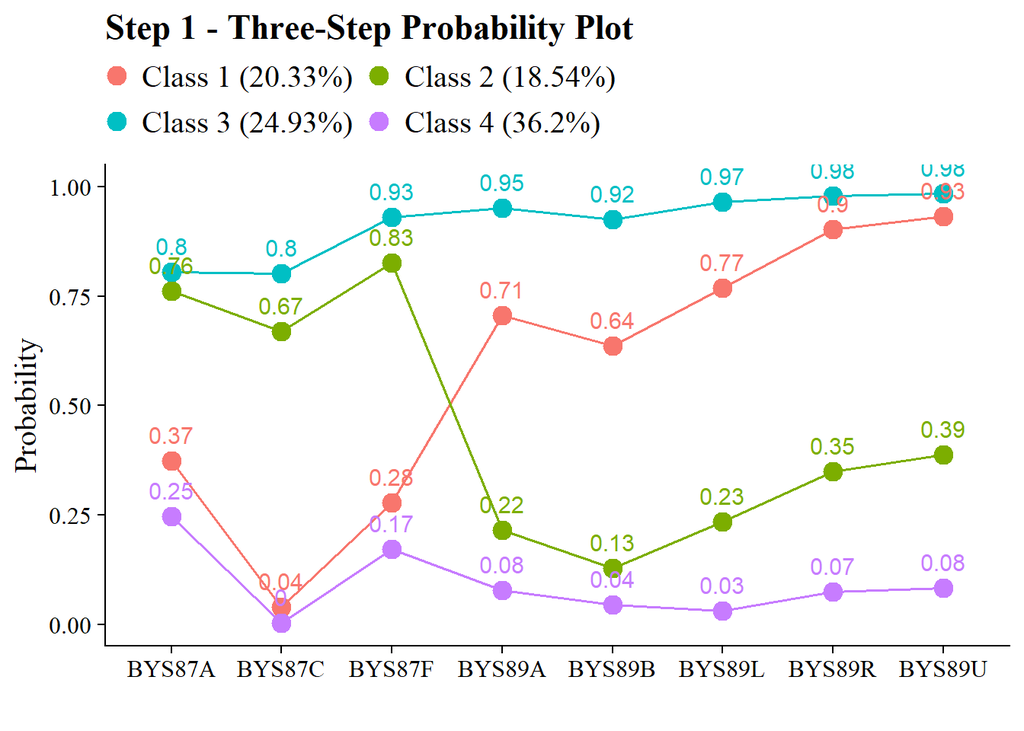

```r
source(here("functions", "plot_lca.R"))
output_one <- readModels(here("three_step", "one.out"))

plot_lca(model_name = output_one)
```

Check that log-likelihood values are the same

```r
output_one <- readModels(here("three_step", "one.out"))
output_one$summaries$LL
```

```
## [1] -45812.59
```

```r
enumeration_c5 <- readModels(here("enumeration", "c4_math_weighted.out"))
enumeration_c5$summaries$LL
```

```
## [1] -45812.59
```

### Step 2 - Determine Measurement Error

Extract logits for the classification probabilities for the most likely latent class

```r
logit_cprobs <- as.data.frame(output_one$class_counts$logitProbs.mostLikely)
logit_cprobs
```

```
##        1      2      3 4
## 1  2.691 -0.448 -0.013 0
## 2 -0.893  1.664 -1.308 0
## 3  3.261  2.159  5.684 0
## 4 -3.825 -3.826 -5.953 0
```

Extract saved dataset from step one

```r
savedata <- as.data.frame(output_one$savedata) %>%
  rename(N = MLCC) #Rename the column in savedata named "MLCC" and change to "N"
```

Check variable names in savedata (Mplus will cut off variable names that are longer than 8 characters)

```r
names(savedata)
```

```
##  [1] "BYS87A"   "BYS87C"   "BYS87F"   "BYS89A"   "BYS89B"   "BYS89L"
##  [7] "BYS89R"   "BYS89U"   "FEMALE"   "SES_DICH" "F3ONET2C" "CPROB1"
## [13] "CPROB2"   "CPROB3"   "CPROB4"   "N"        "F3BYTSCW"
```

### Step 3 - LCA Auxiliary Variable Model with 2 covariates and 1 distal outcome

```r
step3  <- mplusObject(
  TITLE = "Step 3 - Three-Step",

  VARIABLE =
 "nominal=N;
  classes = c(4);
  usevar = N FEMALE SES_DICH F3ONET2C;
  categorical = F3ONET2C;" , # Add covariates and distal outcomes in addition to `N` here

  ANALYSIS =
 "estimator = mlr;
  type = mixture;
  starts = 0;",

  DEFINE =
   "center FEMALE SES_DICH (grandmean);",

  MODEL =
  glue(
 " %OVERALL%

  F3ONET2C on FEMALE SES_DICH; ! covariate as a related to the distal outcome
  C on female (f1-f3);
  C on SES_DICH (s1-s3);

     %C#1%
  [n#1@{logit_cprobs[1,1]}]; ! MUST EDIT if you do not have a 5-class model.
  [n#2@{logit_cprobs[1,2]}];
  [n#3@{logit_cprobs[1,3]}];

  [F3ONET2C$1](m1);    ! conditional distal logit

  %C#2%
  [n#1@{logit_cprobs[2,1]}];
  [n#2@{logit_cprobs[2,2]}];
  [n#3@{logit_cprobs[2,3]}];

  [F3ONET2C$1](m2);

  %C#3%
  [n#1@{logit_cprobs[3,1]}];
  [n#2@{logit_cprobs[3,2]}];
  [n#3@{logit_cprobs[3,3]}];

  [F3ONET2C$1](m3);

  %C#4%
  [n#1@{logit_cprobs[4,1]}];
  [n#2@{logit_cprobs[4,2]}];
  [n#3@{logit_cprobs[4,3]}];

  [F3ONET2C$1](m4);

 "),

 MODELCONSTRAINT =
 "New (
    ! Distal mean differences (6 total for 4 classes)
    diff12 diff13 diff14
    diff23 diff24 diff34
  );

  ! Distal mean comparisons
  diff12 = m1-m2;
  diff13 = m1-m3;
  diff14 = m1-m4;
  diff23 = m2-m3;
  diff24 = m2-m4;
  diff34 = m3-m4;
 ",

  MODELTEST = "     ! omnibus test of distal means
    m1=m2;
    m2=m3;
    m3=m4;

    !f1=0;       ! omnibus test of covariate logits (female)
    !f2=0;
    !f3=0;

    !s1=0;       ! omnibus test of covariate logits (ses)
    !s2=0;
    !s3=0;
   ",

 OUTPUT = "sampstat",

  usevariables = colnames(savedata),
  rdata = savedata)

step3_fit <- mplusModeler(step3,
               dataout=here("three_step", "Step3.dat"),
               modelout=here("three_step", "three_distal.inp"),
               check=TRUE, run = TRUE, hashfilename = FALSE)
```

Rerun model with different model test:

```r
# Update the model test by overwriting string
step3$MODELTEST <- "f1=0; f2=0; f3=0;"

# Then run it again
mplusModeler(step3,
               dataout=here("three_step", "Step3.dat"),
               modelout=here("three_step", "three_female.inp"),
               check=TRUE, run = TRUE, hashfilename = FALSE)
```

Rerun model with different model test:

```r
# Update the model test by overwriting string
step3$MODELTEST <- "s1=0; s2=0; s3=0;"

# Then run it again
mplusModeler(step3,
               dataout=here("three_step", "Step3.dat"),
               modelout=here("three_step", "three_ses.inp"),
               check=TRUE, run = TRUE, hashfilename = FALSE)
```

Compare Step 1 classes and Step 3 classes

```r
output_one <- readModels(here("three_step", "one.out"))
output_one$class_counts$modelEstimated
```

```
##   class    count proportion
## 1     1 2468.993    0.20328
## 2     2 2252.181    0.18543
## 3     3 3028.463    0.24934
## 4     4 4396.363    0.36196
```

```r
output_three <- readModels(here("three_step", "three_distal.out"))
output_three$class_counts$modelEstimated
```

```
##   class    count proportion
## 1     1 2325.724    0.19148
## 2     2 2357.554    0.19410
## 3     3 3066.438    0.25246
## 4     4 4396.284    0.36195
```

NOTE: If there are notable differences between class formation in the Step 1 and the Step 3 models, it means there are one of more covariates included in the Step 3 model that may be sources of unaccounted-for DIF

## Visualizations

#### Wald Test Table

This is testing if there is a relation between the latent class variable and the distal outcome.

```r
# Make a Wald table function
wald_table <- function(mplus_model, table_title) {

  # Read the model
  model_output <- mplus_model

  # Extract information as data frame
  wald <- as.data.frame(model_output[["summaries"]]) %>%
    dplyr::select(WaldChiSq_Value:WaldChiSq_PValue) %>%
    mutate(WaldChiSq_DF = paste0("(", WaldChiSq_DF, ")")) %>%
    unite(wald_test, WaldChiSq_Value, WaldChiSq_DF, sep = " ") %>%
    rename(pval = WaldChiSq_PValue) %>%
    mutate(pval = ifelse(pval<0.001, paste0("<.001*"),
                       ifelse(pval<0.05, paste0(scales::number(pval, accuracy = .001), "*"),
                              scales::number(pval, accuracy = .001))))

  # Create the gt table
  wald %>%
  gt() %>%
    tab_header(
    title = table_title) %>%
    cols_label(
      wald_test = md("Wald Test (*df*)"),
      pval = md("*p*-value")) %>%
  cols_align(align = "center") %>%
  opt_align_table_header(align = "left") %>%
  gt::tab_options(table.font.names = "serif")
}
```

Use `wald_table` funtion

```r
output_three_distal <- readModels(here("three_step", "three_distal.out"))
output_three_female <- readModels(here("three_step", "three_female.out"))
output_three_ses <- readModels(here("three_step", "three_ses.out"))

wald_table(output_three_distal, "Wald Test Distal Means (Math IRT Scores)")
```

| Wald Test (*df*) | *p*-value |
| --- | --- |
| 39.126 (3) | <.001* |

```r
wald_table(output_three_female, "Wald Test Distal Means (Female)")
```

Wald Test Distal Means (Female)

| Wald Test (*df*) | *p*-value |
| --- | --- |
| 171.432 (3) | <.001* |

```r
wald_table(output_three_ses, "Wald Test Distal Means (SES)")
```

Wald Test Distal Means (SES)

| Wald Test (*df*) | *p*-value |
| --- | --- |
| 120.158 (3) | <.001* |

#### Table of Covariates Relations

Make `predictor_table` function

```r
# Make a predictor table function
predictor_table <- function(mplus_output,
                            var_labels = NULL,
                            table_title = "Predictors of Class Membership") {

  # Extract Unstandardized Logits
cov_data <- as.data.frame(mplus_output[["parameters"]][["unstandardized"]]) %>%
  filter(str_detect(paramHeader, "\\.ON$")) %>%
  filter(!str_detect(LatentClass, "Categorical\\.Latent\\.Variables")) %>%
  mutate(
    param_label = if (!is.null(var_labels)) {
      str_replace_all(param, var_labels)
    } else {
      str_to_title(param)
    },
    latent_class = paste("Class", LatentClass)
  ) %>%
  mutate(
    logit = paste0(format(round(est, 3), nsmall = 3), " (", format(round(se, 2), nsmall = 2), ")"),
    pval_label = case_when(
      pval < 0.001 ~ "<.001*",
      pval < 0.05  ~ paste0(scales::number(pval, accuracy = .001), "*"),
      TRUE         ~ scales::number(pval, accuracy = .001)
    )
  ) %>%
  dplyr::select(param_label, latent_class, logit, pval_label)

  # Extract Odds Ratios
  or_data <- as.data.frame(mplus_output[["parameters"]][["odds"]]) %>%
    filter(str_detect(paramHeader, "\\.ON$")) %>%
    mutate(
      param_label = if (!is.null(var_labels)) {
        str_replace_all(param, var_labels)
      } else {
        str_to_title(param)
      },

      latent_class = paste("Class", LatentClass),

      CI = paste0("[", format(round(lower_2.5ci, 3), nsmall = 3), ", ",
                  format(round(upper_2.5ci, 3), nsmall = 3), "]")
    ) %>%
    dplyr::select(param_label, latent_class, or = est, CI)

  # Combine and Format Table
  or_data %>%
    full_join(cov_data, by = c("param_label", "latent_class")) %>%
    dplyr::select(param_label, latent_class, logit, pval_label, or, CI) %>%
    gt(groupname_col = "latent_class", rowname_col = "param_label") %>%
    tab_header(title = table_title) %>%
    cols_label(
      logit = md("Logit (*se*)"),
      or = md("Odds Ratio"),
      CI = md("95% CI"),
      pval_label = md("*p*-value")
    ) %>%
    sub_missing(missing_text = "-") %>%
    cols_align(align = "center") %>%
    opt_align_table_header(align = "left") %>%
    gt::tab_options(table.font.names = "serif")
}
```

Use `predictor_table` function

```r
output_three <- readModels(here("three_step", "three_distal.out"))

predictor_table(output_three, var_labels = c("FEMALE" = "Female", "SES_DICH" = "SES"))
```

|  | Logit (*se*) | *p*-value | Odds Ratio | 95% CI |
| --- | --- | --- | --- | --- |
| Class 1 |  |  |  |  |
| Female | -0.221 (0.05) | <.001* | 0.801 | [0.732, 0.877] |
| SES | -0.336 (0.06) | <.001* | 0.715 | [0.635, 0.805] |
| Class 2 |  |  |  |  |
| Female | -0.221 (0.05) | <.001* | 0.801 | [0.732, 0.877] |
| SES | -0.336 (0.06) | <.001* | 0.715 | [0.635, 0.805] |
| Class 3 |  |  |  |  |
| Female | -0.221 (0.05) | <.001* | 0.801 | [0.732, 0.877] |
| SES | -0.336 (0.06) | <.001* | 0.715 | [0.635, 0.805] |
| Class 4 |  |  |  |  |
| Female | -0.221 (0.05) | <.001* | 0.801 | [0.732, 0.877] |
| SES | -0.336 (0.06) | <.001* | 0.715 | [0.635, 0.805] |

#### Plot of Gender Differences

Class 1 = Low Math Attitudes, High Self-Efficacy (20.33%) Class 2 = High Math Attitudes, Low Self-Efficacy (18.546%) Class 3 = High Math Attitudes, High Self-Efficacy (24.93%) Class 4 = Low Math Attitudes, Low Self-Efficacy (36.2%)

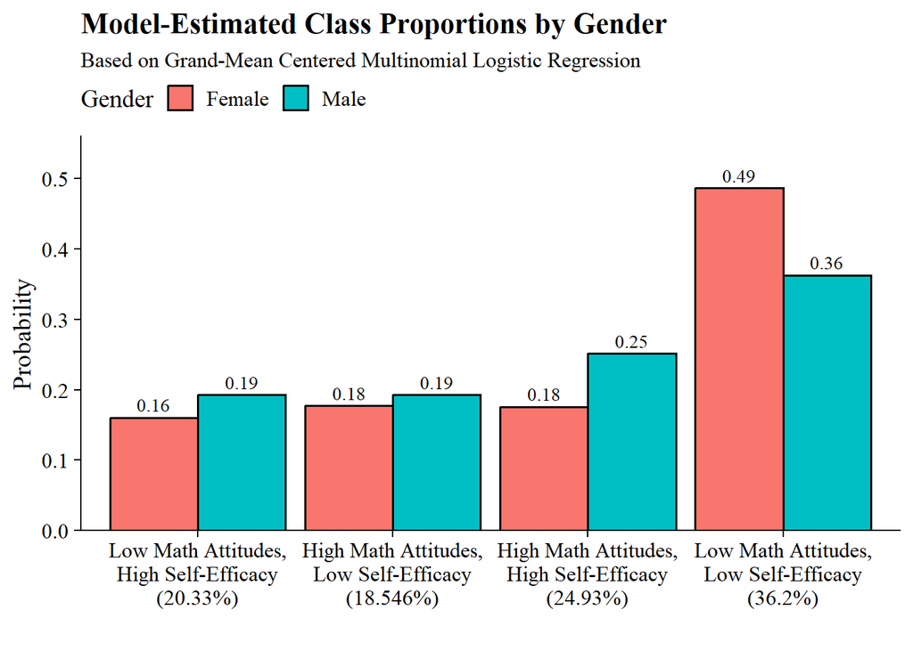

```r
output_three <- readModels(here("three_step", "three_distal.out"))

# Extract Centering Values from Univariate Stats
# These are the values Mplus used for the 'Female' variable after centering
female_x   <- savedata %>% summarize(max_val = max(FEMALE, na.rm = TRUE)) %>% pull(max_val)
male_x <- savedata %>% summarize(min_val = min(FEMALE, na.rm = TRUE)) %>% pull(min_val)

# Extract Intercepts and Slopes from Parameters
params <- as.data.frame(output_three$parameters$unstandardized)

# Get Intercepts (C#1 to C#4)
intercepts <- params %>%
  filter(paramHeader == "Intercepts" & str_detect(param, "C#")) %>%
  mutate(Class = as.numeric(str_extract(param, "\\d+"))) %>%
  select(Class, intercept = est)

# Get Slopes (C#1.ON to C#4.ON)
slopes <- params %>%
  filter(str_detect(paramHeader, "C#\\d+\\.ON") & param == "FEMALE") %>%
  mutate(Class = as.numeric(str_extract(paramHeader, "\\d+"))) %>%
  select(Class, slope = est)

# Merge and add the Reference Class (Class 4), which is fixed to 0 in your model
logits_df <- full_join(intercepts, slopes, by = "Class") %>%
  add_row(Class = 4, intercept = 0, slope = 0) %>%
  arrange(Class)

# Class labels
class_labels <- c("1" = "Low Math Attitudes, High Self-Efficacy (20.33%)",
                  "2" = "High Math Attitudes, Low Self-Efficacy (18.546%)",
                  "3" = "High Math Attitudes, High Self-Efficacy (24.93%)",
                  "4" = "Low Math Attitudes, Low Self-Efficacy (36.2%)")

# Calculate Predicted Probabilities
plot_data <- logits_df %>%
  # Create a row for each gender within each class
  crossing(Gender = c("Male", "Female")) %>%
  mutate(
    # Use centered values: Male (-0.485) and Female (0.515)
    x_val = ifelse(Gender == "Male", male_x, female_x),
    logit = intercept + (slope * x_val)
  ) %>%
  group_by(Gender) %>%
  mutate(
    # Apply Softmax: P = exp(logit) / sum(exp(logits))
    prob = exp(logit) / sum(exp(logit)),
    Class_Name = str_wrap(class_labels[as.character(Class)], width = 20)
  )

# Generate the Plot
ggplot(plot_data, aes(x = fct_inorder(Class_Name), y = prob, fill = Gender)) +
  geom_bar(stat = "identity", position = position_dodge(width = 0.9), color = "black") +
  geom_text(aes(label = sprintf("%.2f", prob)),
            position = position_dodge(width = 0.9),
            vjust = -0.5, size = 3.5, family = "serif") +
  scale_y_continuous(expand = expansion(mult = c(0, 0.15))) +
  labs(
    title = "Model-Estimated Class Proportions by Gender",
    subtitle = "Based on Grand-Mean Centered Multinomial Logistic Regression",
    x = "",
    y = "Probability",
    fill = "Gender"
  ) +
  theme_cowplot() +
  theme(
    text = element_text(family = "serif"),
    panel.grid.major.x = element_blank(),
    legend.position = "top"
  )
```

#### Plot of SES Differences

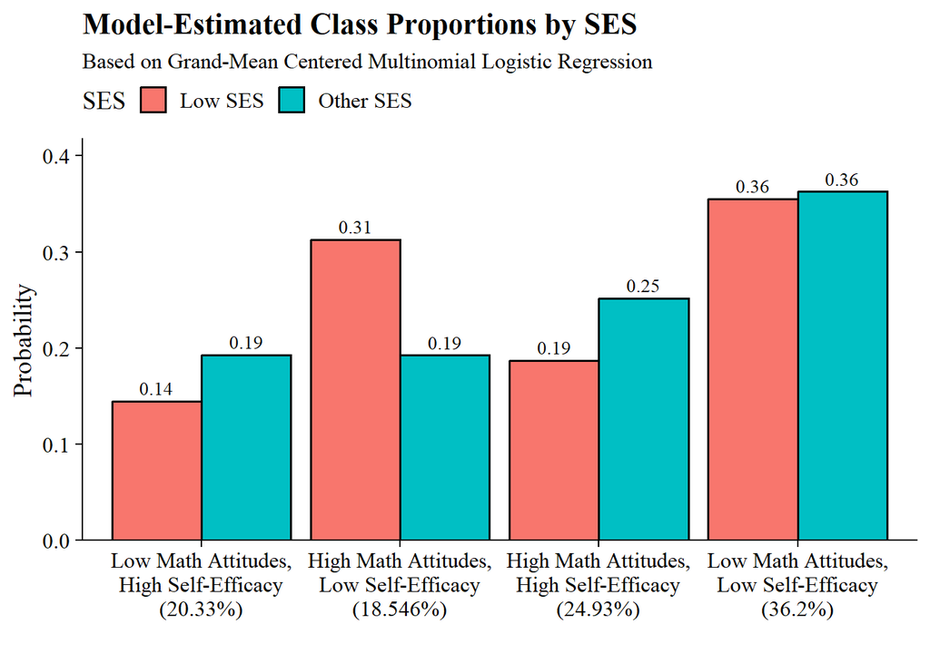

```r
output_three <- readModels(here("three_step", "three_distal.out"))

# Extract Centering Values from Univariate Stats
# These are the values Mplus used for the 'Female' variable after centering
low_ses_x   <- savedata %>% summarize(max_val = max(SES_DICH, na.rm = TRUE)) %>% pull(max_val)
other_ses_x <- savedata %>% summarize(min_val = min(SES_DICH, na.rm = TRUE)) %>% pull(min_val)

# Extract Intercepts and Slopes from Parameters
params <- as.data.frame(output_three$parameters$unstandardized)

# Get Intercepts (C#1 to C#4)
intercepts <- params %>%
  filter(paramHeader == "Intercepts" & str_detect(param, "C#")) %>%
  mutate(Class = as.numeric(str_extract(param, "\\d+"))) %>%
  select(Class, intercept = est)

# Get Slopes (C#1.ON to C#4.ON)
slopes <- params %>%
  filter(str_detect(paramHeader, "C#\\d+\\.ON") & param == "SES_DICH") %>%
  mutate(Class = as.numeric(str_extract(paramHeader, "\\d+"))) %>%
  select(Class, slope = est)

# Merge and add the Reference Class (Class 5), which is fixed to 0 in your model
logits_df <- full_join(intercepts, slopes, by = "Class") %>%
  add_row(Class = 4, intercept = 0, slope = 0) %>%
  arrange(Class)

# Class labels
class_labels <- c("1" = "Low Math Attitudes, High Self-Efficacy (20.33%)",
                  "2" = "High Math Attitudes, Low Self-Efficacy (18.546%)",
                  "3" = "High Math Attitudes, High Self-Efficacy (24.93%)",
                  "4" = "Low Math Attitudes, Low Self-Efficacy (36.2%)")

# Calculate Predicted Probabilities
plot_data <- logits_df %>%
  # Create a row for each gender within each class
  crossing(SES = c("Other SES", "Low SES")) %>%
  mutate(
    # Use centered values: Male (-0.485) and Female (0.515)
    x_val = ifelse(SES == "Other SES", other_ses_x, low_ses_x),
    logit = intercept + (slope * x_val)
  ) %>%
  group_by(SES) %>%
  mutate(
    # Apply Softmax: P = exp(logit) / sum(exp(logits))
    prob = exp(logit) / sum(exp(logit)),
    Class_Name = str_wrap(class_labels[as.character(Class)], width = 20)
  )

# Generate the Plot
ggplot(plot_data, aes(x = fct_inorder(Class_Name), y = prob, fill = SES)) +
  geom_bar(stat = "identity", position = position_dodge(width = 0.9), color = "black") +
  geom_text(aes(label = sprintf("%.2f", prob)),
            position = position_dodge(width = 0.9),
            vjust = -0.5, size = 3.5, family = "serif") +
  scale_y_continuous(expand = expansion(mult = c(0, 0.15))) +
  labs(
    title = "Model-Estimated Class Proportions by SES",
    subtitle = "Based on Grand-Mean Centered Multinomial Logistic Regression",
    x = "",
    y = "Probability",
    fill = "SES"
  ) +
  theme_cowplot() +
  theme(
    text = element_text(family = "serif"),
    panel.grid.major.x = element_blank(),
    legend.position = "top"
  )
```

#### Table of Pairwise Distal Outcome Differences

Make `diff_table` function

```r
diff_table <- function(mplus_output,
                       prefix = "DIFF",
                       table_title = "Pairwise Comparisons") {

  # Extract and Clean
  diff_data <- as.data.frame(mplus_output[["parameters"]][["unstandardized"]]) %>%
    # Dynamically filter by the prefix provided (e.g., DIFF or FEM)
    filter(str_detect(param, paste0("^", prefix))) %>%
    dplyr::select(param, est, se, pval) %>%
    # Format Estimate and SE
    mutate(
      estimate = paste0(format(round(est, 3), nsmall = 3),
                        " (", format(round(se, 2), nsmall = 2), ")")
    ) %>%
    # Logic to split "DIFF12" into "1" and "2"
    mutate(
      digits = str_remove(param, prefix),
      Group1 = substr(digits, 1, 1),
      Group2 = substr(digits, 2, 2),
      comparison = paste0("Class ", Group1, " vs. Class ", Group2)
    ) %>%
    # Format p-values
    mutate(pval_label = case_when(
      pval < 0.001 ~ "<.001*",
      pval < 0.05  ~ paste0(scales::number(pval, accuracy = .001), "*"),
      TRUE         ~ scales::number(pval, accuracy = .001)
    )) %>%
    dplyr::select(comparison, estimate, pval_label)

  # Create Table
  diff_data %>%
    gt() %>%
    tab_header(title = table_title) %>%
    cols_label(
      comparison = "Comparison",
      estimate = md("Difference (*se*)"),
      pval_label = md("*p*-value")
    ) %>%
    cols_align(align = "center") %>%
    opt_align_table_header(align = "left") %>%
    gt::tab_options(table.font.names = "serif")
}
```

Use `diff_table` function

```r
output_three <- readModels(here("three_step", "three_distal.out"))

diff_table(
  mplus_output = output_three,
  prefix = "DIFF",
  table_title = "Pairwise Comparisons of Distal Outcome (STEM Occupation)"
)
```

Pairwise Comparisons of Distal Outcome (STEM Occupation)

| Comparison | Difference (*se*) | *p*-value |
| --- | --- | --- |
| Class 1 vs. Class 2 | -0.037 (0.10) | 0.709 |
| Class 1 vs. Class 3 | 0.296 (0.08) | <.001* |
| Class 1 vs. Class 4 | -0.082 (0.08) | 0.299 |
| Class 2 vs. Class 3 | 0.332 (0.09) | <.001* |
| Class 2 vs. Class 4 | -0.045 (0.09) | 0.601 |
| Class 3 vs. Class 4 | -0.378 (0.06) | <.001* |

#### Plot Distal Outcome Means

[figure not shown]

```r
output_three <- readModels(here("three_step", "three_distal.out"))

plot_data <- data.frame(
  class_w_label = c(
    "Low Math Attitudes,\nHigh Self-Efficacy (20.33%)",
    "High Math Attitudes,\nLow Self-Efficacy (18.55%)",
    "High Math Attitudes,\nHigh Self-Efficacy (24.93%)",
    "Low Math Attitudes,\nLow Self-Efficacy (36.2%)"
  ),
  est = c(24.6, 24.0, 30.5, 23.1)
)

# Plot bar graphs
plot_data %>%
  ggplot(aes(x=class_w_label, y = est, fill = class_w_label)) +
  geom_col(position = "dodge", stat = "identity", color = "black") +
  geom_text(aes(label = paste0(est, "%")),
            family = "serif", size = 4,
            position=position_dodge(.9),
            vjust = 8) +
 # scale_fill_grey(start = .4, end = .7) + # Remove for colorful bars
  labs(y="STEM Occupation", x="",
           title = "Distal Mean Comparision for STEM Occupation") +
  theme_cowplot() +
  theme(text = element_text(family = "serif"),
        legend.position="none")
```

#### Distal outcome regressed on the covariate

```r
output_three <- readModels(here("three_step", "three_distal.out"))

# Extract information as data frame
donx <- as.data.frame(output_three[["parameters"]][["unstandardized"]]) %>%
  filter(!str_detect(LatentClass, "Categorical\\.Latent\\.Variables")) %>%
  filter(param %in% c("FEMALE", "SES_DICH")) %>%
  mutate(param = str_replace(param, "FEMALE", "Female"),
         param = str_replace(param, "SES_DICH", "SES")) %>%
  mutate(LatentClass = sub("^","Class ", LatentClass)) %>%
  dplyr::select(!paramHeader) %>%
  mutate(se = paste0("(", format(round(se,2), nsmall =2), ")")) %>%
    unite(estimate, est, se, sep = " ") %>%
  dplyr::select(param, estimate, pval) %>%
  distinct(param, .keep_all=TRUE) %>%
  mutate(pval = ifelse(pval<0.001, paste0("<.001*"),
                       ifelse(pval<0.05, paste0(scales::number(pval, accuracy = .001), "*"),
                              scales::number(pval, accuracy = .001))))

# Create table
donx %>%
  gt(groupname_col = "LatentClass", rowname_col = "param") %>%
  tab_header(
    title = "Covariates Predicting STEM Occupation") %>%
  cols_label(
    estimate = md("Estimate (*se*)"),
    pval = md("*p*-value")) %>%
  sub_missing(1:3,
              missing_text = "") %>%
  sub_values(values = c("999.000"), replacement = "-") %>%
  cols_align(align = "center") %>%
  opt_align_table_header(align = "left") %>%
  gt::tab_options(table.font.names = "serif")
```

Covariates Predicting STEM Occupation

|  | Estimate (*se*) | *p*-value |
| --- | --- | --- |
| Female | -0.221 (0.05) | <.001* |
| SES | -0.336 (0.06) | <.001* |

[figure not shown]